# Approximation

Michael Liou

12/22/2021

# Edgeworth Expansion

Edgeworth expansion is an improvement to the normal approximation that includes skewness (degree 2) and kurtosis (degree three). The first degree approximation amounts to the normal approximation.

Suppose we have a general distribution $X_i$ with mean $\mu$ and variance $\sigma^2$. If we standardize the sum, we have a statistic that is approximately N$(0, 1)$

$$\begin{aligned}
Z = \frac{1}{\sqrt{n}} \sum_i \frac{X_i - \mu}{\sigma}
\end{aligned}$$
Edgeworth expansion of the pdf of $Z$ is

$$\begin{aligned}
f_Z(z) = \underbrace{\underbrace{\underbrace{\phi(z)}_{\text{degree 1}} + \frac{\lambda_3}{6\sqrt{n}}H_3(z)\phi(z)}_{\text{degree 2}} + \left(\frac{\lambda_4}{24n}H_4(z)\phi(z) + \frac{\lambda_3^2}{72n}H_6(z)\phi(z)\right)}_{\text{degree 3}} + o\left(\frac{1}{n}\right)
\end{aligned}$$
where:

- $\lambda_r$ denotes the cumulant of Z, related to the cumulants of $X_i$ by $\lambda_r = \kappa_r / \sigma^r$ if cumulants of $X_i$ are represented by $\kappa_r$
- $H_r$ are hermite polynomials.

We look at how well this approximation works for the sum of chisq random variables. The cumulants of the chisq variables.

Suppose $X_i \sim \chi^2_2$

If we study the mean, the true distribution is $\bar{X_i} \sim \Gamma(\frac{n * df}{2}, \frac{n}{2})$.

```r
set.seed(1)
n <- 3

# Sampled distribution
rand_x <- rchisq(1000, 2) + rchisq(1000, 2) + rchisq(1000, 2)
rand_x_mean <- rand_x / n

# True distribution
# Gamma(3, 3/2)
x <- seq(0, 10, by=.1)
true_y <- dgamma(x, 3, 3/2)

# Normal Approximation
# N(2, 4/3)
norm_approx_y <- dnorm(x, mean = 2, sd = sqrt(4/3))
```

For the edgeworth expansion, since we’re studying the mean $\bar X$, this is a transformation of $Z$, that is,

$$\begin{aligned}
\bar X = \frac{(Z\sqrt{n\sigma^2} + n\mu)}{n}
\end{aligned}$$
so the inverse formula that we use in the pdf transformation formula,

$$\begin{aligned}
Z = \frac{n\bar X - n\mu}{\sqrt{n\sigma^2}}
\end{aligned}$$
The transformation formula would then say,

$$\begin{aligned}
f_{\bar X}(x) &= \underbrace{f_Z\left(\frac{nx - n\mu}{\sqrt{n\sigma^2}}\right)}_{\text{approximated by Edgeworth}} \left| \frac{\sqrt{n}}{\sigma}\right|
\end{aligned}$$

```r
herm <- Vectorize(function(x, degree = 1 ) {
  switch(degree,
         x,
         x^2 -1,
         x^3 - 3*x,
         x^4 - 6*x^2 + 3,
         x^5 - 10 * x^3 + 15 * x,
         x^6 - 15*x^4 + 45*x^2 - 15)
}, "x")


# Edgeworth expansion, degree 2
edgeworth_mean2 <- function(x, n, mu, sigma2, lambda3){
  z <- sqrt(n) * (x - mu) / sqrt(sigma2)
  sqrt(n / sigma2) * dnorm(z) * (1 + lambda3 / (6 * sqrt(n)) * herm(z, 3))
}

# Edgeworth expansion, degree 3
edgeworth_mean3 <- function(x, n, mu, sigma2, lambda3, lambda4) {
  z <- sqrt(n) * (x - mu) / sqrt(sigma2) # transformation
  sqrt(n / sigma2) * # transformation scaling
    dnorm(z) * (1 +  # degree 1 terms
      lambda3 / (6 * sqrt(n)) * herm(z, 3) + # degree 2 terms
      lambda4 / (24 * n) * herm(z, 4) + # degree 3 terms
      lambda3^2 / (72 * n) * herm(z, 6)) # degree 3 terms
}
```

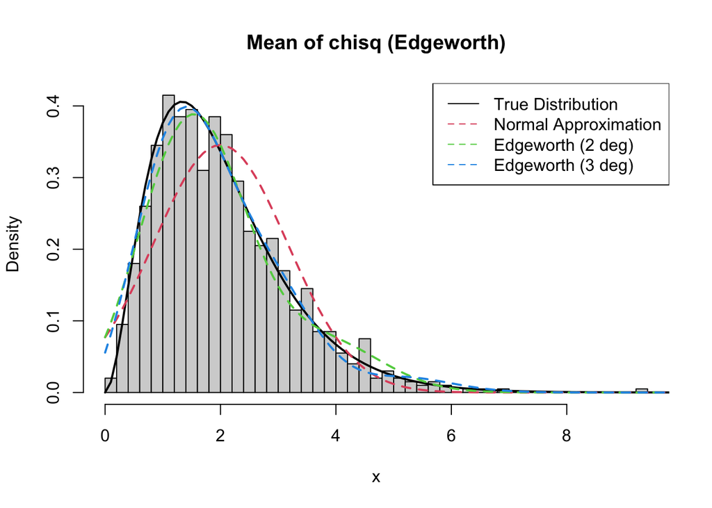

```r
# Creating unified plot with all the
hist(rand_x_mean, breaks=50, freq = FALSE, main = "Mean of chisq (Edgeworth)", xlab = "x")
lines(x, true_y, lwd = 2)
lines(x, norm_approx_y, lty = 2, col = 2, lwd = 2)
lines(x, edgeworth_mean2(x, 3, 2, 4, 2), lty = 2, col = 3, lwd = 2)
lines(x, edgeworth_mean3(x, 3, 2, 4, 2, 6), lty = 2, col = 4, lwd = 2)
legend("topright",
       legend = c("True Distribution",
                  "Normal Approximation",
                  "Edgeworth (2 deg)",
                  "Edgeworth (3 deg)"),
       col = c(1, 2, 3, 4),
       lty = c(1, 2, 2, 2))
```

## R Packages

- EW
  - does finite differencing for the moment estimators
  - only two functions, edgeworth and saddlepoint approximations
- EQL (extended quasi likelihood)
  - does extended quasi-likelihood and saddlepoint approximations too
  - in my opinion, very well written and clear readable code. Used source code to figure out my own errors.

```r
library(EQL)
```

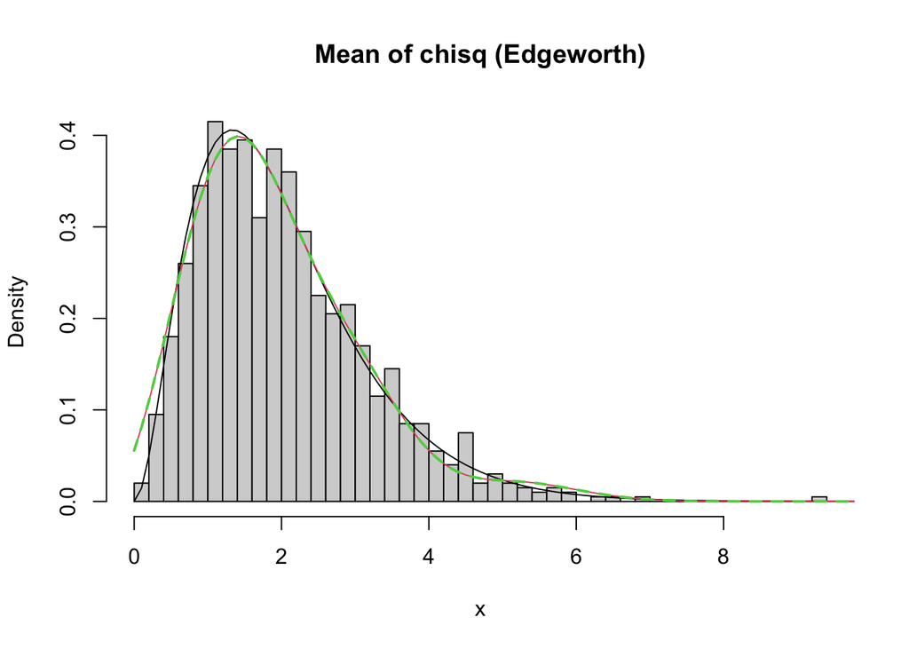

```r
# Usage for our example
ew <- edgeworth(x, n = 3, mu = 2, sigma2 = 4, rho3 = 2, rho4 = 6, type = "mean", deg = 3)

# They match with our results
hist(rand_x_mean, breaks=50, freq = FALSE, main = "Mean of chisq (Edgeworth)", xlab = "x")
lines(x, true_y)
lines(x, edgeworth_mean3(x, 3, 2, 4, 2, 6), col = 2)
lines(x, ew$approx, lty = 2, lwd = 2, col = 3)
```

# Saddlepoint Approximation

- https://stats.stackexchange.com/questions/191492/how-does-saddlepoint-approximation-work/191781